# Nelineární optimalizace a KKT podmínky

MPC-OMM · přednáška 3

Tomáš Vičar

Ústav biomedicínského inženýrství · FEKT VUT

2026-10-07

## Po dnešku byste měli umět…

Sestavit kvadratickou úlohu

Kdy zadání přestává být lineární — a jak z něj vzniknou $Q$, $\mathbf c$, $A$ a $\mathbf b$?

*Pekárna se slevou, ridge regrese, SVM: pořád jeden a týž zápis.*

Poznat, že jsem v optimu

Omezení nahradíme **cenou za porušení**; čtyři **KKT podmínky** poznají, že je ta správná.

*Buď je omezení napnuté, nebo je jeho cena nulová.*

Přečíst multiplikátor

Co znamená číslo, které solver vrátí ke **každému omezení** — a proč dává zaručenou **mez optima** (dualita)?

*Stínová cena z minula konečně dostane jméno.*

Vědět, kde končí solver

Co za nás spočítá software — a která práce zůstane nám?

*Solver vrátí čísla; úlohu za nás nesestaví.*

## Kam jsme došli minule

### Co z LP umíme

- **zadání do matic**: $\min \mathbf c^\mathsf T\mathbf x$ za $A\mathbf x\leq \mathbf b$, $\mathbf x\geq\mathbf 0$;
- **geometrie**: přípustná oblast je polyedr, optimum leží ve **vrcholu**;
- **řešení**: simplex chodí po vrcholech a vrátí certifikát optimality;
- **navíc zdarma**: stínové ceny říkají, kolik nás stojí napnuté omezení.

Pekárna skončila v optimu $(100,150)$ se ziskem **2600 Kč**.

### Co dnes přibude: zakřivení

- chyba se měří **kvadraticky**, ne lineárně;
- omezení může být zakřivené: „nepřekroč celkovou energii“ je koule;
- pekárna: **čím víc napečeme, tím víc musíme slevit** — zisk z kusu už není pevný.

A jedna nepříjemnost: až se vrstevnice zakřiví, přestane platit rada „hledej optimum ve vrcholech“.

Dobrá zpráva: **zápis úlohy se nemění.** Mění se jen *tvar* účelové funkce a omezení — a s ním to, kde se optimum může schovat.

## 1 · Od přímek k zakřivenému světu

> Minule stačilo, aby všechno bylo přímé. Jakmile se cena, chyba nebo dávka začne chovat kvadraticky, přestane platit i to nejcennější, co jsme měli: že optimum sedí ve vrcholu.

## Kde linearita praská

[figure not shown]

- **Chyba se měří kvadraticky:** minimalizujeme $\sum_i r_i^2$ — velká odchylka bolí neúměrně víc než malá.
- **Omezení je zakřivené:** limit energie svazků $\|\mathbf x\|^2\leq E$ je koule, ne polorovina.
- **Nelineární je rovnou model:** v $c(t)=c_0\mathrm e^{-kt}$ sedí hledané $k$ v exponentu.

První dvě situace vedou na **kvadratické programování (QP)**, které se řeší skoro stejně spolehlivě jako LP; třetí je obecná nelineární úloha.

## Když se vrstevnice zakřiví

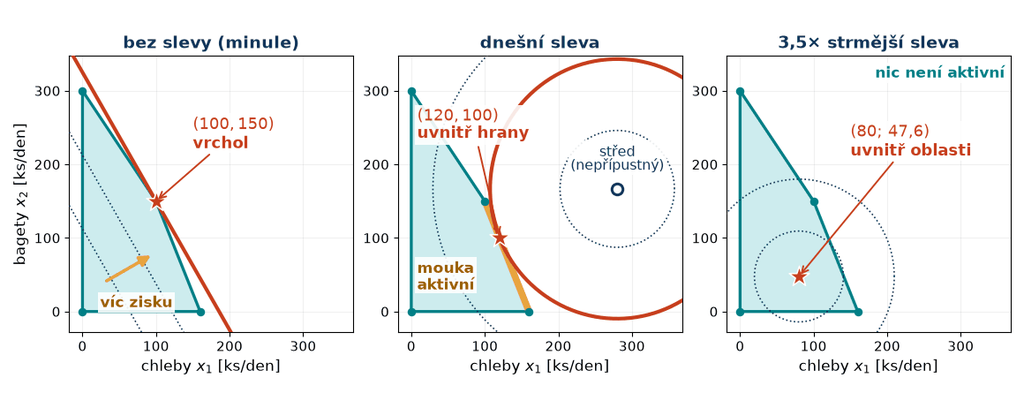

Oblast je všude **stejná**, mění se jen účel. Vrstevnice zisku se posouvá, dokud se oblasti ještě **dotýká** — poslední dotyk je optimum.

**Základní věta LP tím padá.** Optimum může ležet uprostřed hrany, nebo dokonce uvnitř oblasti. Procházet vrcholy nestačí — potřebujeme podmínku, která pozná optimum kdekoli.

## Kvadratické programování

$$\min_{\mathbf x}\;\; \tfrac12\mathbf x^\mathsf TQ\mathbf x+\mathbf c^\mathsf T\mathbf x
\qquad\text{subject to}\qquad A\mathbf x\leq \mathbf b$$

Nová je jen symetrická matice $Q$: číslo $\mathbf d^\mathsf TQ\mathbf d$ je **zakřivení ve směru $\mathbf d$** (červeně $\mathbf d=(1,0)$, oranžově $(0,1)$).

[figure not shown]

Účelová funkce je **konvexní, právě když $Q\succeq0$** (zakřivení nikde záporné). Pak je konvexní celá úloha a platí: **lokální minimum je globální.**

## Mapa tříd úloh

[figure not shown]

Hranice mezi „vyřešeno“ a „něco najdeme“ nevede mezi lineárním a nelineárním, ale mezi **konvexním a nekonvexním**: **nekonvexní QP** ($Q$ má někde záporné zakřivení) je už NP-těžké. Zbytek přednášky se drží uvnitř červené čáry.

**Jak poznám konvexitu složitější funkce?** Skládá se z konvexních cihel ($x^2$, $\mathrm e^x$, $-\log x$, normy) pravidly, která ji zachovávají: **nezáporná kombinace**, **maximum**, **dosazení** $A\mathbf x+\mathbf b$. Přesně to hlídá CVXPY; `DCPError` znamená „takhle zapsané to neumím ověřit“, ne „úloha nemá řešení“.

## 2 · Katalog kvadratických úloh

> Pekárna, regularizace i klasifikátor jsou tatáž úloha. Umět to poznat je pořád ta těžší půlka práce — solver čeká jen na $Q$, $\mathbf c$, $A$ a $\mathbf b$.

## Pekárna podruhé: zisk z kusu klesá s objemem

Minule vydělal chléb pevných 14 Kč a bageta 8 Kč. Víc chleba ale trh za plnou cenu nevezme a sleva jde ze zisku: **marže (zisk z kusu) klesá s množstvím.**

$$p_1(x_1)=14-0{,}025\,x_1,\qquad p_2(x_2)=8-0{,}024\,x_2$$

[figure not shown]

Zisk = marže × množství, $p_i(x_i)\,x_i$: součin dvou lineárních výrazů je **kvadratický**. Omezení se nezměnila ani o písmeno.

## Pekárna jako QP ve standardním tvaru

### Zadání s čísly

$x_1$ chleby, $x_2$ bagety [ks/den]; mouka a pec beze změny z minula:

$$\begin{aligned}
\text{maximize}\quad & \color{#007F86}{14}\,x_1+\color{#007F86}{8}\,x_2
-\color{#C73E1D}{0{,}025}\,x_1^2-\color{#C73E1D}{0{,}024}\,x_2^2\\
\text{subject to}\quad & 0{,}5x_1+0{,}2x_2\leq80\\
& 3x_1+2x_2\leq600\\
& x_1\geq0,\quad x_2\geq0
\end{aligned}$$

Proti minulé přednášce přibyly **jen ty dva kvadratické členy**.

### Standardní tvar

$$\begin{aligned}
\text{minimize}\quad & \tfrac12\mathbf x^\mathsf TQ\mathbf x+\mathbf c^\mathsf T\mathbf x\\
\text{subject to}\quad & A\mathbf x\leq \mathbf b,\quad \mathbf x\geq\mathbf 0
\end{aligned}$$

$$Q=\begin{bmatrix}\color{#C73E1D}{0{,}05}&0\\0&\color{#C73E1D}{0{,}048}\end{bmatrix},\qquad
\mathbf c=\begin{bmatrix}\color{#007F86}{-14}\\\color{#007F86}{-8}\end{bmatrix}$$

$$A=\begin{bmatrix}0{,}5&0{,}2\\3&2\end{bmatrix},\qquad
\mathbf b=\begin{bmatrix}80\\600\end{bmatrix}$$

**Tři kroky:** ① maximum otočíme na minimum, $\max f=-\min(-f)$ — proto mínusy v $\mathbf c$; ② **kvadratické** členy jdou do $Q$ **dvakrát**, protože vzorec má $\tfrac12$: $Q_{11}=2\cdot0{,}025$; ③ **lineární** jdou do $\mathbf c$, řádky omezení beze změny do $A$ a $\mathbf b$.

**Výsledek:** $\mathbf x^\star=(120,100)$ ks/den, zisk **1880 Kč**; mouka padne beze zbytku (**aktivní**), na peci zbývá 40 minut (**neaktivní**). Minule 2600 Kč — rozdíl je celý ta sleva, kterou lineární model neznal.

## Regularizace: pokuta místo omezení

Chyba proložení $\|A\mathbf x-\mathbf b\|^2$ (rozepíšeme ji v příštím bloku) plus malé řešení — jako **pokuta** (ridge), nebo jako **rozpočet** ([spustitelná ukázka](https://github.com/tomasvicar/OMM-public/blob/master/prednasky/L3/kod/qp_priklady_cvxpy.py)):

$$\min_{\mathbf x}\ \|A\mathbf x-\mathbf b\|^2+\alpha\|\mathbf x\|^2
\qquad\Longleftrightarrow\qquad
\min_{\mathbf x}\ \|A\mathbf x-\mathbf b\|^2\ \ \text{s.t.}\ \ \|\mathbf x\|^2\leq t$$

**síla pokuty α**

**Táž úloha:** ke každému $\alpha>0$ existuje $t$, a ke každému $t$, které řešení opravdu svírá, existuje $\alpha$. To $\alpha$ **je optimální multiplikátor** omezení $\|\mathbf x\|^2\leq t$ — vrátíme se k tomu u lagrangiánu.

## SVM: největší odstup mezi třídami

Klasifikace pacientů ze dvou příznaků: $\mathbf z_i$ jsou příznaky pacienta $i$, $y_i=\pm1$ jeho třída. Dělicích přímek je nekonečně mnoho — vybereme tu s **největším odstupem** od obou tříd:

$$\begin{aligned}
\text{minimize}\quad & \tfrac12\|\mathbf w\|^2\\
\text{subject to}\quad & y_i(\mathbf w^\mathsf T\mathbf z_i+b_0)\geq1
\end{aligned}$$

Odstup je $2/\|\mathbf w\|$, takže **menší norma $\mathbf w$ = širší odstup**. Každý pacient dá jeden řádek omezení: „buď na své straně, a s rezervou“. Zase QP; podrobnosti znáte z předmětů o strojovém učení ([ukázka na GitHubu](https://github.com/tomasvicar/OMM-public/blob/master/prednasky/L3/kod/qp_priklady_cvxpy.py)).

[figure not shown]

Pekárna, ridge i SVM jsou **tentýž zápis**. Liší se jen tím, **co je $Q$** (sleva, pokuta za velikost, jednotková matice) a **co znamenají řádky $A$** (surovina, rozpočet, pacient). Support vektory jsou přesně ta **aktivní omezení** z první přednášky.

## 3 · Bez omezení: jak poznám minimum

> Nejdřív ta snadná situace, kde nás nic nesvírá. Všechno ostatní se na ni bude převádět.

## Podmínka optimality bez omezení

V první přednášce jsme minimum spotřeby auta našli tam, kde $f'(v^\star)=0$ a $f''(v^\star)>0$. Ve více proměnných nahradí derivaci **gradient** — sloupec parciálních derivací. Derivujeme vždy podle jedné proměnné a ostatní držíme jako konstanty:

$$\nabla f(\mathbf x)=
\begin{bmatrix}\partial f/\partial x_1\\\vdots\\\partial f/\partial x_n\end{bmatrix}$$

Šipka $\nabla f$ míří **nejstrměji do kopce** a stojí kolmo na vrstevnici. Na dně už nemá kam ukázat — to je **nutná podmínka 1. řádu**: vnitřní lokální minimum diferencovatelné funkce je **stacionární bod**,

$$\nabla f(\mathbf x^\star)=\mathbf 0 .$$

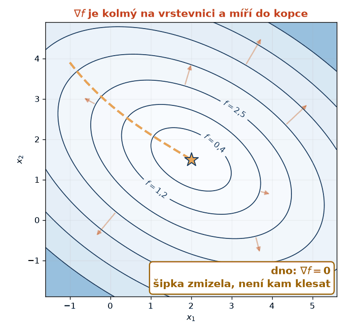

Podmínka je **nutná, ne postačující**: nulový gradient má i vrchol kopce a sedlo. Gradient vybere kandidáty, rozhodnou až druhé derivace.

## Spočítejme to ručně: gradient a Hessián

Pekárna s klesající marží. Maximalizaci zisku otočíme na minimalizaci, tedy $f(\mathbf x)=0{,}025x_1^2+0{,}024x_2^2-14x_1-8x_2$.

**1 · Gradient** — derivujeme podle jedné proměnné, druhá je konstanta:

$$\nabla f(\mathbf x)=
\begin{bmatrix}0{,}05x_1-14\\0{,}048x_2-8\end{bmatrix}
=Q\mathbf x+\mathbf c$$

**2 · Stacionární bod** z $\nabla f=\mathbf 0$ — dvě rovnice, každá o jedné neznámé:

$$x_1=\frac{14}{0{,}05}=280,\qquad x_2=\frac{8}{0{,}048}\doteq166{,}7$$

**3 · Hessián** je druhá derivace ve více proměnných: každou složku gradientu zderivujeme ještě jednou podle každé proměnné. Vznikne čtvercová tabulka:

$$\nabla^2 f=
\begin{bmatrix}
\dfrac{\partial^2 f}{\partial x_1^2} & \dfrac{\partial^2 f}{\partial x_1\partial x_2}\\[8pt]
\dfrac{\partial^2 f}{\partial x_2\partial x_1} & \dfrac{\partial^2 f}{\partial x_2^2}
\end{bmatrix}
=\begin{bmatrix}0{,}05&0\\0&0{,}048\end{bmatrix}=Q$$

Na diagonále je **zakřivení podél os** (jako $f''$ u auta), mimo diagonálu to, jak se sklon ve směru $x_1$ mění s $x_2$. Tady jsou tam nuly, protože v $f$ chybí člen $x_1x_2$. U kvadratické funkce je Hessián **všude stejný** a rovná se $Q$.

Kandidát $(280;\,166{,}7)$ ale **není přípustný**: mouky by padlo 173 kg místo dostupných 80. Celý zbytek přednášky je o tom, co s podmínkou optimality, když do ní mluví omezení.

## Tři druhy stacionárních bodů

[figure not shown]

Hessián měří zakřivení: ve směru $\mathbf d$ je to číslo $\mathbf d^\mathsf TQ\mathbf d$. Kladné ve **všech** směrech je minimum, záporné ve všech maximum, obojí sedlo.

Nejstrmější a nejplošší zakřivení jsou **vlastní čísla** $Q$: $\det Q$ je jejich součin, $\operatorname{tr}Q$ součet — tabulka proto platí jen pro **2×2**. Z diagonály samotné se typ přečíst nedá. Pekárna má $\det Q>0$ i $\operatorname{tr}Q>0$: **minimum**.

| $\det Q$ | $\operatorname{tr}Q$ | bod |
| --- | --- | --- |
| $>0$ | $>0$ | **minimum** |
| $>0$ | $<0$ | **maximum** |
| $<0$ | cokoli | **sedlo** |
| $=0$ | cokoli | nerozhodne |

**Je-li $f$ konvexní** ($\nabla^2f\succeq0$ všude), je každý stacionární bod rovnou **globálním minimem** — podmínka $\nabla f=\mathbf 0$ pak i stačí. Proto se v optimalizaci pořád mluví o konvexitě.

## Nejmenší čtverce: normální rovnice

„Trefit se do dat“ znamená minimalizovat součet čtverců reziduí $\|A\mathbf x-\mathbf b\|^2$. Po roznásobení je to QP s $Q=2A^\mathsf TA$ a $\mathbf c=-2A^\mathsf T\mathbf b$:

$$\|A\mathbf x-\mathbf b\|^2
=\mathbf x^\mathsf TA^\mathsf TA\,\mathbf x-2\mathbf b^\mathsf TA\mathbf x
+\mathbf b^\mathsf T\mathbf b$$

Gradient položíme roven nule a vydělíme dvěma — vyjdou **normální rovnice**:

$$\boxed{\;A^\mathsf TA\,\mathbf x=A^\mathsf T\mathbf b\;}$$

Obyčejná soustava lineárních rovnic; přesně tohle počítá každá lineární regrese. Hessián $2A^\mathsf TA\succeq0$, takže úloha je **vždy konvexní**. Jediné řešení ale potřebuje $A$ s plnou sloupcovou hodností — jinak pomůže **ridge** z minulého bloku.

[figure not shown]

Týž vzorec řeší **regresi a kalibraci**, **rekonstrukci obrazu** i **radioterapii** z první přednášky: tam je $A_{ij}$ dávka do tkáně $i$ z jednotkové intenzity svazku $j$ a cílem „trefit se předpisu co nejblíž“.

Jenže intenzita svazku nemůže být záporná — a jakmile přibude $\mathbf x\geq\mathbf 0$, žádný uzavřený vzorec nestačí.

## 4 · Omezení jako pokuta a zeď

> Neomezené úlohy už umíme. Tak z omezené udělejme neomezenou — a za porušení omezení si necháme zaplatit.

## K čemu je to dobré

- **Bez omezení to umíme.** Minimum poznáme podle $\nabla f=\mathbf 0$ a příští přednáška ukáže, jak k němu dojít. Tyhle metody ale omezení neznají.
- **PyTorch a spol. berou jedinou funkci.** „Intenzita nesmí být záporná“ se do nich dostane jen jako další člen v účelu.
- **Už jsme to viděli:** ridge regrese je pokuta $\alpha\|\mathbf x\|^2$ místo rozpočtu na velikost koeficientů. A metoda vnitřního bodu uvnitř solveru dělá totéž.

**Omezená úloha**

$\min f(\mathbf x)$ za $g_i(\mathbf x)\leq0$

→

**Pokuta, nebo zeď**

omezení se stane členem v účelu s parametrem $\rho$ či $t$

→

**Posloupnost neomezených úloh**

parametr postupně roste

→

**Gradientní metody**

příští přednáška

Dvě podoby téhož triku: **pokuta** nás za hranici pustí a naúčtuje si to, **bariéra** (zeď) nás k hranici vůbec nepustí.

## Od maticového zápisu k obecným omezením

### Obecná úloha

$$\begin{aligned}
\text{minimize}\quad & f(\mathbf x)\\
\text{subject to}\quad & g_i(\mathbf x)\leq0, && i=1,\dots,m\\
& h_j(\mathbf x)=0, && j=1,\dots,p
\end{aligned}$$

Jediná konvence, zato bez výjimky: **všechno na jednu stranu, napravo nula.** Tvar $A\mathbf x\leq \mathbf b$ z minula je speciální případ s lineárními $g_i$; dnes už smějí být i **zakřivené**.

### Pekárna přepsaná

$$\begin{aligned}
0{,}5x_1+0{,}2x_2\leq80
&\;\;\longrightarrow\;\; g_1(\mathbf x)=0{,}5x_1+0{,}2x_2-80\leq0\\
3x_1+2x_2\leq600
&\;\;\longrightarrow\;\; g_2(\mathbf x)=3x_1+2x_2-600\leq0\\
x_1\geq0,\;x_2\geq0
&\;\;\longrightarrow\;\; g_3=-x_1\leq0,\;\; g_4=-x_2\leq0
\end{aligned}$$

Nezápornost je omezení jako každé jiné. Hodnoty v optimu $\mathbf x^\star=(120,100)$:

| omezení | $g_i(\mathbf x^\star)$ | stav |
| --- | --- | --- |
| mouka | $0$ | napnuté — mouka došla |
| pec | $-40$ | rezerva 40 minut |
| $x_1\geq0$, $x_2\geq0$ | $-120$, $-100$ | hluboko volné |

Hodnota $g_i$ tím dostane **význam**: $g_i=0$ je napnuté omezení, $g_i<0$ je velikost rezervy, $g_i>0$ je **překročení**.

## Omezení jako pokuta

Omezení **nevyřešíme, ale zpoplatníme**:

$$\min_{\mathbf x}\;f(\mathbf x)+\rho\sum_i\max\bigl(0,\,g_i(\mathbf x)\bigr)^2$$

Uvnitř oblasti pokuta nic nestojí, venku roste s druhou mocninou překročení. Rovnost by se trestala za odchylku na obě strany, členem $\rho\,h_j(\mathbf x)^2$.

**Malé $\rho$:** pokuta se vyplatí, řešení je daleko venku. **Velké $\rho$:** řešení se přitiskne k hranici — ale vždy **zvenku**. Desetkrát větší $\rho$, desetkrát menší překročení.

**Kolik stojí poslední kilo navíc?** Sklon pokuty, $2\rho\cdot$překročení. Tuhle **cenu mouky** označíme $\mu_1$ — s rostoucím $\rho$ se ustálí na pevném čísle.

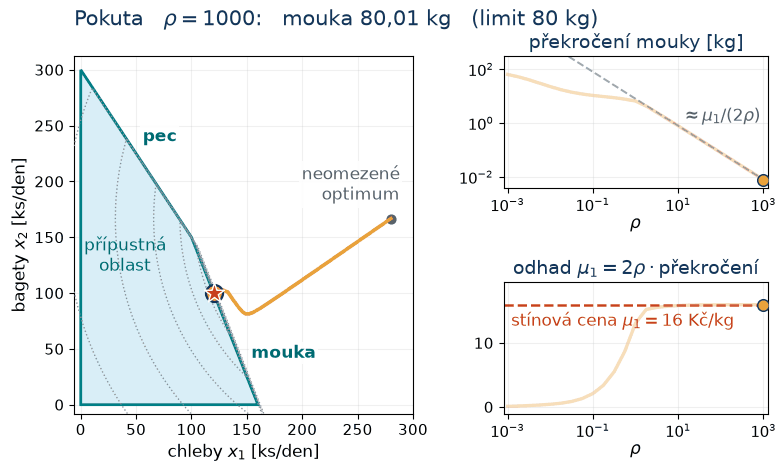

Omezení je tak jen **měkké**: pro každé konečné $\rho$ splněné přibližně. U zašuměných dat je to ctnost, u dávky do kritického orgánu vada.

## Bariéra: zůstaň uvnitř

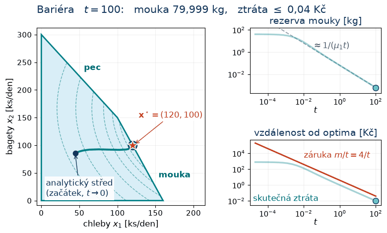

Opačný nápad: před hranici postavíme **zeď**.

$$\min_{\mathbf x}\;f(\mathbf x)-\frac1t\sum_i\log\bigl(-g_i(\mathbf x)\bigr)$$

Uvnitř je $-g_i>0$ (rezerva); u hranice jde logaritmus do $-\infty$ a celý člen do $+\infty$. Řešení je proto vždy **přípustné** — start ale musí ležet uvnitř.

Body pro rostoucí $t$ tvoří **centrální cestu**: z analytického středu (tlustá zeď) až do $\mathbf x^\star=(120,100)$. To je **metoda vnitřního bodu**, kterou minulá přednáška odbyla jednou větou.

**I zeď účtuje.** Sklon zdi u mouky je $1/(t\cdot\text{rezerva})$ Kč za kilo — a s rostoucím $t$ se taky ustálí.

Každou z neomezených úloh uvnitř řeší **Newtonova metoda** (v každém kroku kvadratická aproximace); příbuzná **SQP** řeší posloupnost QP úloh. To je práce solveru — **naše práce je úloha.**

## Pokuta, nebo bariéra?

ρ = t = 100

|  | pokuta | bariéra |
| --- | --- | --- |
| k hranici jde | **zvenku** | **zevnitř** |
| cestou přípustná | ne | ano |
| start | kdekoli | uvnitř oblasti |
| mouka proti limitu | +0,08 kg | −0,00063 kg |
| cena mouky $\mu_1$ | $2\rho$ × překročení = 15,99 | 1 / ($t$ × rezerva) = 16,00 |
| záruka | — | ztráta ≤ $4/t$ = 0,04 Kč |

**Za přesnost se platí.** Velké $\rho$ či $t$ udělá z údolí úzkou rokli: u pekárny roste poměr největšího a nejmenšího zakřivení zhruba jako $12\rho$. Proto se parametr zvyšuje **postupně** a každá úloha startuje z minulého řešení. Jak se téhle daně vyhnout, ukáže další blok.

Posuvníkem se mění oba parametry najednou. Výpočet běží přímo ve slidu; animace a čísla ověřuje obrazky_blok7.py.

## Obě cesty vedou k jedné ceně

[figure not shown]

Pokuta i zeď v řešení **účtují za kilo mouky cenu** — a s rostoucím parametrem je to pokaždé **16 Kč/kg**.

To je **stínová cena mouky**: kilo mouky navíc přidá zhruba 16 Kč zisku (limit 81 kg dá 1895,9 Kč místo 1880). Minule u LP to bylo 10 Kč/kg.

**Pec** má rezervu 40 minut — pokuta za ni nic nevybere, zeď je daleko, její cena jde k **nule**.

Pokuta i zeď nakonec účtují za kilo mouky stejných 16 Kč. **Co kdybychom tu cenu znali předem?** Pak by stačil obyčejný lineární poplatek — a to je **lagrangián**.

Obrázek kreslí obrazky_blok4_cena.py stejnými výpočty jako obě animace.

## 5 · Lagrangián a KKT: pokuta se správnou cenou

> Nepotřebujeme nekonečně strmou pokutu. Stačí obyčejný poplatek — jen musí mít správnou cenu. KKT jsou pravidla, podle kterých tu cenu poznáme.

## Lineární poplatek místo pokuty

Mouku zrušíme jako omezení a zavedeme **poplatek**: za kilo nad 80 kg pekař zaplatí $\mu$ Kč, za ušetřené kilo dostane $\mu$ Kč zpět. Úloha je pak **bez omezení**.

Pro minimalizaci ($f$ je záporný zisk) je to **Lagrangeova funkce**:

$$\mathcal L(\mathbf x,\mu)=f(\mathbf x)+\mu\,g_1(\mathbf x)$$

s omezením mouky $g_1(\mathbf x)=0{,}5x_1+0{,}2x_2-80\leq0$.

- zadarmo ($\mu=0$) chce plán 173 kg mouky;
- při $\mu=16$ Kč/kg leží plán **přesně na hranici** mouky — v optimu $(120;\,100)$.

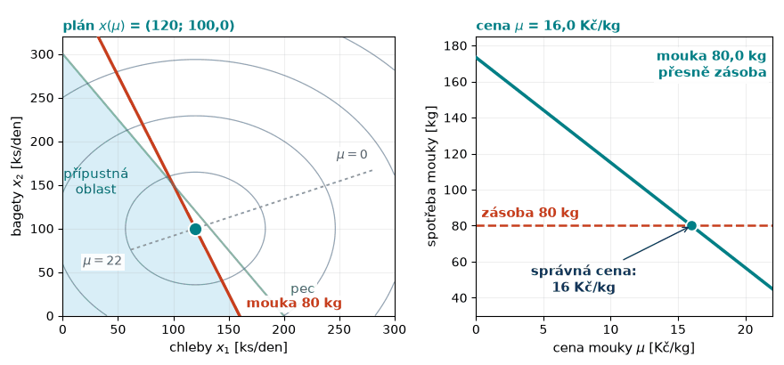

**Multiplikátor $\mu$ je cena omezení** — stínová cena (*shadow price*) mouky z konce minulého bloku. Stačí znát správné číslo a nic nemusí jít do nekonečna (u konvexní úlohy, jako je pekárna).

## V optimu jsou gradienty rovnoběžné

Co platí při správné ceně geometricky? Nejjednodušší je **rovnost** $h(\mathbf x)=0$ s cenou $\lambda$ (napnutá mouka se chová stejně). $\mathbf x^\star$ je stacionární bod lagrangiánu, takže

$$\nabla f(\mathbf x^\star)+\lambda\,\nabla h(\mathbf x^\star)=\mathbf 0 .$$

- Na omezení gradient **nemizí** — volné minimum $f$ (šedě) leží mimo.
- Svírají-li $\nabla f$ a $\nabla h$ úhel, dá se po omezení ještě klesat (oranžově).
- V optimu jsou **rovnoběžné**: vrstevnice se omezení jen dotkne.

[interactive chart not shown]

Rovnoběžnost je **důsledek** poplatku: tah účelu vyrovná odpor omezení.

## Čtyři pravidla pro správnou cenu

Každé omezení dostane **svou cenu** — nerovnosti $g_i\leq0$ cenu $\mu_i$, rovnosti $h_j=0$ cenu $\lambda_j$ — a poplatky se sečtou:

$$\mathcal L(\mathbf x,\boldsymbol\mu,\boldsymbol\lambda)
=f(\mathbf x)+\sum_i\mu_i\,g_i(\mathbf x)+\sum_j\lambda_j\,h_j(\mathbf x)$$

Cena je **správná** a $\mathbf x^\star$ je **optimum**, když platí:

| pravidlo | zápis | řečí ceny |
| --- | --- | --- |
| **stacionarita** | $\nabla f+\sum_i\mu_i\nabla g_i+\sum_j\lambda_j\nabla h_j=\mathbf 0$ | tah účelu vyrovnají ceny omezení |
| **primární přípustnost** | $g_i\leq0,\;\;h_j=0$ | bod zadání neporušuje |
| **duální přípustnost** | $\mu_i\geq0$ ($\lambda_j$ libovolné) | za překročení se platí, nedostává se zaplaceno |
| **komplementarita** | $\mu_i\,g_i=0$ | za rezervu se neplatí |

KKT = **Karushovy–Kuhnovy–Tuckerovy podmínky**. První pravidlo je lagrangián, zbylé tři hlídají, aby cena dávala smysl.

U **konvexní** úlohy kdo splní KKT, je v globálním optimu — a optimum je vždy splní, existuje-li bod, kde všechny nerovnosti platí ostře (**Slaterova podmínka**). Mimo konvexní svět jsou jen **nutné**: najdou kandidáty, vybrat musíme sami.

## Buď je omezení napnuté, nebo je jeho cena nulová

**Za rezervu se neplatí.** Obě možnosti shrne jediný součin — **komplementarita** (*complementary slackness*):

$$\mu_i\,g_i(\mathbf x^\star)=0$$

- **mouka:** $g_1=0$, cena $\mu_1=16$ Kč/kg;
- **pec:** $g_2=-40$ minut, cena $\mu_2=0$.

Když pec zmenšíme a napne se, cena se **přestěhuje** z mouky na pec.

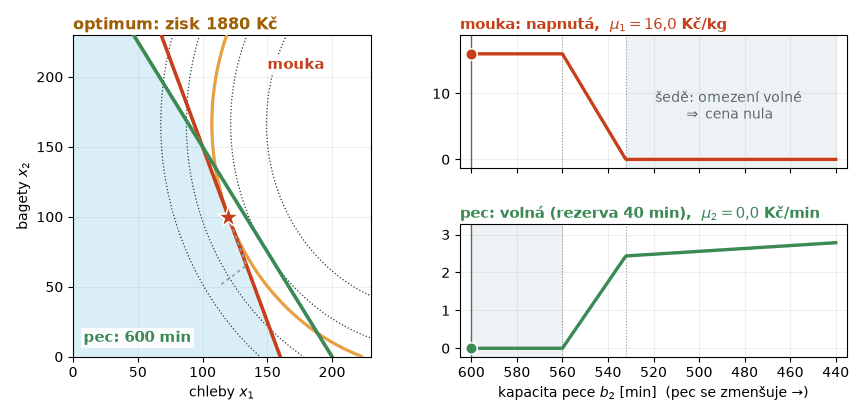

Co má rezervu, je zadarmo.

## KKT ručně: tipni, dopočítej, ověř

KKT nejsou jen kontrolní seznam pro hotový bod. Jsou to **rovnice**, takže z nich optimum i cenu můžeme **najít**.

**Dávka léku:** ideál jsou 3 mg, předpis dovoluje nejvýš 2 mg.

$$\min_x\;(x-3)^2\quad\text{subject to}\quad g(x)=x-2\leq0$$

Lagrangián $(x-3)^2+\mu(x-2)$; stacionarita $\;2(x-3)+\mu=0$. To je jedna rovnice pro dvě neznámé. Druhou dodá komplementarita — jenže nevíme, kterou půlku. **Zkusíme obě:**

| tip | dopočítáme | ověříme |
| --- | --- | --- |
| volný, $\mu=0$ | $x=3$ | $g=1>0$ ✗ porušuje limit |
| napnutý, $x=2$ | $\mu=-2(2-3)=2$ | $\mu\geq0$ ✓ **optimum** |

Při limitu **5 mg** projde naopak první tip ($x=3$, $g=-2$) a druhý padne na $\mu=-4<0$.

[figure not shown]

Sklon křivky v optimu je $-2$, tedy $\mu=2$: povolí-li předpis o 0,1 mg víc, odchylka klesne zhruba o $0{,}2$.

**Primární přípustnost** odhalí omezení, které jsme mylně pustili, **znaménko ceny** omezení, které jsme mylně napnuli. Kdo projde obojím, je optimum.

## KKT v praxi: solver to spočítá za nás

```python
# Q, c, A, b jsou konstanty pekárny
x = cp.Variable(2)
zdroje = A @ x <= b                  # g1, g2 <= 0
uloha = cp.Problem(
    cp.Minimize(0.5 * cp.quad_form(x, Q) + c @ x),
    [zdroje, x >= 0])
uloha.solve()

mu = zdroje.dual_value               # multiplikátory
print(mu * (A @ x.value - b))        # komplementarita
print(Q @ x.value + c + A.T @ mu)    # stacionarita (x* > 0)
```

```
x* = [120. 100.]   zisk = 1880 Kč
mu = [16.  0.]
komplementarita = [ 4.5e-13 -0.0e+00]
stacionarita    = [-1.1e-13 -8.8e-14]
```

[Zdroj ukázky na GitHubu](https://github.com/tomasvicar/OMM-public/blob/master/prednasky/L3/kod/qp_pekarna_cvxpy.py)

Kromě řešení vrátí solver ke **každému omezení** jeho cenu: `mu = [16, 0]` — mouka 16 Kč/kg, pec s rezervou nula.

Oba tištěné výrazy jsou nula na strojovou přesnost a $\boldsymbol\mu\geq\mathbf 0$, takže platí **všechna čtyři** pravidla — u konvexní úlohy je to **certifikát** globálního optima.

Ručně jen u dvou tří omezení: tipů, která omezení jsou napnutá, je $2^m$.

## Odbočka: kdo je K, K a T

Zkratka **KKT** má tři písmena, ale dlouho měla jen dvě. Podmínky odvodil **William Karush** už v roce 1939 ve své diplomové práci — nepublikoval ji a nikdo si jí nevšiml. V roce 1951 je znovu objevili **Harold Kuhn** a **Albert Tucker** v pořádně vydaném článku a dalších dvacet let se jim říkalo Kuhn–Tuckerovy podmínky.

Karushovo prvenství se připomnělo až v sedmdesátých letech — mimo jiné proto, že se za něj přimluvil sám Kuhn. Diplomka se tedy vyplatí publikovat.

## 6 · Dualita: hledání správné ceny

> Správnou cenu jsme zatím dopočítali z KKT. Dá se ale hledat i přímo — jako samostatná úloha o cenách. Tím splatíme dluh z minulé přednášky: odkud se berou stínové ceny a proč solver ví, že líp to nejde.

## Každá cena dá mez

Dávka: $\min\,(x-3)^2$ za $x-2\leq0$, optimum $p^\star=1$.

**Na přípustném bodě poplatek jen vrací:** $g(x)\leq0$ a $\mu\geq0$, takže $\mu\,g(x)\leq0$.

Dno lagrangiánu

$$d(\mu)=\min_x\mathcal L(x,\mu)$$

proto leží **pod optimem** — pro **každou** cenu $\mu\geq0$.

- všechny křivky procházejí bodem $(2;\,1)$: na limitu se neplatí nic;
- nejvýš je dno při $\mu=2$ — tatáž cena jako z KKT.

[figure not shown]

Každá cena dá zaručenou mez optima, aniž bychom optimum znali. Hledat **nejlepší** mez je **duální úloha**.

## Lagrangián jako hra o cenu

Dva hráči: **lékař** volí dávku $x$ a chce $\mathcal L$ co nejmenší, **kontrolor** volí cenu $\mu\geq0$ a chce $\mathcal L$ co největší.

**Táhne-li první lékař**, kontrolor odpoví:

$$\max_{\mu\geq0}\mathcal L(x,\mu)=
\begin{cases}
f(x) & \text{if } g(x)\leq0\\
+\infty & \text{otherwise}
\end{cases}$$

Omezení zmizela do hry — to je **primár**: $\;p^\star=\min_x\max_{\mu\geq0}\mathcal L$.

**Táhne-li první kontrolor**, je to **duál**: $\;d^\star=\max_{\mu\geq0}\min_x\mathcal L$.

**Slabá dualita** — kdo táhne druhý, nedopadne hůř:

$$\max_{\mu\geq0}\,\min_x\,\mathcal L\;\leq\;\min_x\,\max_{\mu\geq0}\,\mathcal L$$

[figure not shown]

**Silná dualita = sedlový bod:** v $(x^\star,\mu^\star)=(2;\,2)$ si nikdo nepolepší, ať táhne první kdokoli — a $\mathcal L=1=p^\star=d^\star$.

## Duální úloha: jak se sestrojí

**Primár:** $\;\text{minimize } f(\mathbf x)\;\text{ subject to }\; g_i(\mathbf x)\leq0,\;h_j(\mathbf x)=0\;\;\to\;p^\star$

**1 · Lagrangián** — každé omezení dostane cenu:

$$\mathcal L(\mathbf x,\boldsymbol\mu,\boldsymbol\lambda)
=f(\mathbf x)+\sum_i\mu_i\,g_i(\mathbf x)+\sum_j\lambda_j\,h_j(\mathbf x)$$

**2 · Duální funkce** — nejlepší $\mathbf x$ při pevných cenách, bez omezení:

$$d(\boldsymbol\mu,\boldsymbol\lambda)=\inf_{\mathbf x}\,
\mathcal L(\mathbf x,\boldsymbol\mu,\boldsymbol\lambda)$$

**3 · Duální úloha** — nejlepší mez:

$$\text{maximize}\;\; d(\boldsymbol\mu,\boldsymbol\lambda)
\;\;\text{subject to}\;\; \boldsymbol\mu\geq\mathbf 0
\qquad\to\; d^\star$$

**Proč je to mez (slabá dualita).** Pro přípustné $\mathbf x$ a $\boldsymbol\mu\geq\mathbf 0$:

$$\begin{aligned}
d(\boldsymbol\mu,\boldsymbol\lambda)
&\leq\mathcal L(\mathbf x,\boldsymbol\mu,\boldsymbol\lambda)\\
&=f(\mathbf x)+\underbrace{\textstyle\sum_i\mu_i g_i(\mathbf x)}_{\leq\,0}
+\underbrace{\textstyle\sum_j\lambda_j h_j(\mathbf x)}_{=\,0}\\
&\leq f(\mathbf x)
\end{aligned}$$

takže $d^\star\leq p^\star$.

**Na dávce:**

1. $\mathcal L=(x-3)^2+\mu\,(x-2)$
2. $x=3-\tfrac{\mu}{2}$, $\;d(\mu)=\mu-\tfrac{\mu^2}{4}$
3. $\mu^\star=2$, $\;d^\star=1=p^\star$

Infimum smí vyjít $-\infty$ — taková cena žádnou mez nedá (uvidíme u LP). Funkce $d$ je vždy konkávní, takže duál je konvexní úloha, i když primár není.

## Duál obecného LP: odvozený, ne spadlý z nebe

**Primár:** $\;\text{minimize } \mathbf c^\mathsf T\mathbf x\;\text{ subject to }\; A\mathbf x\geq\mathbf b,\;\mathbf x\geq\mathbf 0$

**1 ·** Ceny (u LP je značíme $\mathbf y$ jako minule) $\mathbf y\geq\mathbf 0$ za $\mathbf b-A\mathbf x\leq\mathbf 0$ a $\mathbf s\geq\mathbf 0$ za $-\mathbf x\leq\mathbf 0$; přeskupíme podle $\mathbf x$:

$$\mathcal L=\mathbf c^\mathsf T\mathbf x+\mathbf y^\mathsf T(\mathbf b-A\mathbf x)-\mathbf s^\mathsf T\mathbf x
=\mathbf b^\mathsf T\mathbf y+(\mathbf c-A^\mathsf T\mathbf y-\mathbf s)^\mathsf T\mathbf x$$

**2 ·** $\mathcal L$ je v $\mathbf x$ **lineární** — infimum je konečné, jen když je závorka nulová:

$$d(\mathbf y,\mathbf s)=
\begin{cases}
\mathbf b^\mathsf T\mathbf y & \text{if } A^\mathsf T\mathbf y+\mathbf s=\mathbf c\\
-\infty & \text{otherwise}
\end{cases}$$

**3 ·** $\mathbf s\geq\mathbf 0$ je jen *slack*, zbude $A^\mathsf T\mathbf y\leq\mathbf c$.

**Duál:**

$$\begin{aligned}
\text{maximize}\quad & \mathbf b^\mathsf T\mathbf y\\
\text{subject to}\quad & A^\mathsf T\mathbf y\leq\mathbf c,\;\;\mathbf y\geq\mathbf 0
\end{aligned}$$

| primár | duál |
| --- | --- |
| $\min\ \mathbf c^\mathsf T\mathbf x$ | $\max\ \mathbf b^\mathsf T\mathbf y$ |
| omezení $i$: $(A\mathbf x)_i\geq b_i$ | cena $y_i\geq0$ |
| proměnná $x_k\geq0$ | omezení $k$: $(A^\mathsf T\mathbf y)_k\leq c_k$ |

**Slabá dualita na jeden řádek:**

$$\mathbf c^\mathsf T\mathbf x\;\geq\;\mathbf y^\mathsf T A\mathbf x\;\geq\;\mathbf b^\mathsf T\mathbf y$$

Duál LP je zase LP. Role se prohodí: $\mathbf c\leftrightarrow\mathbf b$, $A\leftrightarrow A^\mathsf T$, min ↔︎ max, omezení ↔︎ proměnné.

## Duál pekárny: řádky a sloupce jedné tabulky

[figure not shown]

Pekárna z minula **maximalizuje** s omezeními $\leq$ — je to tatáž dvojice čtená obráceně:

$$\begin{aligned}
\max\ \mathbf c^\mathsf T\mathbf x,\;\; & A\mathbf x\leq\mathbf b,\;\;\mathbf x\geq\mathbf 0\\
\longleftrightarrow\;\;
\min\ \mathbf b^\mathsf T\mathbf y,\;\; & A^\mathsf T\mathbf y\geq\mathbf c,\;\;\mathbf y\geq\mathbf 0
\end{aligned}$$

**Jak to číst:** konkurent chce pekárně odkoupit mouku a čas pece. Za suroviny na jeden chléb musí dát aspoň tolik, kolik chléb vydělá — jinak si ho pekař upeče. A chce zaplatit co nejméně.

Ceny z minula $\mathbf y^\star=(10;\,3)$ dají $80\cdot10+600\cdot3=2600$ Kč — přesně zisk plánu $(100;\,150)$.

Stínové ceny z minulé přednášky jsou **řešením duálu**.

## Nelineární duál: SVM

**Primár** z katalogu: $\;\min\tfrac12\|\mathbf w\|^2\;$ za $\;1-y_i(\mathbf w^\mathsf T\mathbf z_i+b_0)\leq0$ ($y_i=\pm1$ je třída), ceny $\mu_i\geq0$.

**1 · Lagrangián** — roznásobit a seskupit podle neznámých:

$$\begin{aligned}
\mathcal L&=\tfrac12\|\mathbf w\|^2+\textstyle\sum_i\mu_i\bigl(1-y_i(\mathbf w^\mathsf T\mathbf z_i+b_0)\bigr)\\
&=\underbrace{\tfrac12\mathbf w^\mathsf T\mathbf w-\mathbf w^\mathsf T\textstyle\sum_i\mu_i y_i\mathbf z_i}_{\text{only }\mathbf w}
+\underbrace{\textstyle\sum_i\mu_i}_{\text{constant}}
-\underbrace{b_0\textstyle\sum_i\mu_i y_i}_{\text{linear in }b_0}
\end{aligned}$$

**2 · Infimum:** derivace podle $\mathbf w$ je nula; v $b_0$ je $\mathcal L$ lineární (jako u LP):

$$\mathbf w=\sum_i\mu_i\,y_i\,\mathbf z_i,
\qquad
\sum_i\mu_i\,y_i=0$$

**3 · Dosadit zpět:** část s $\mathbf w$ dá $\tfrac12\|\mathbf w\|^2-\|\mathbf w\|^2=-\tfrac12\|\mathbf w\|^2$, člen s $b_0$ zmizí:

$$\|\mathbf w\|^2=\Bigl(\sum_i\mu_iy_i\mathbf z_i\Bigr)^{\!\mathsf T}\Bigl(\sum_j\mu_jy_j\mathbf z_j\Bigr)
=\sum_{i,j}\mu_i\mu_j\,y_iy_j\,\mathbf z_i^\mathsf T\mathbf z_j$$

[figure not shown]

**Duál:**

$$\begin{aligned}
\text{maximize}\quad & \sum_i\mu_i-\tfrac12\sum_{i,j}\mu_i\mu_j\,y_iy_j\,\mathbf z_i^\mathsf T\mathbf z_j\\
\text{subject to}\quad & \boldsymbol\mu\geq\mathbf 0,\;\;\textstyle\sum_i\mu_i y_i=0
\end{aligned}$$

$d^\star=p^\star=0{,}25$, $\;\mathbf w=(0{,}5;\,0{,}5)$ ([kód](https://github.com/tomasvicar/OMM-public/blob/master/prednasky/L3/kod/qp_priklady_cvxpy.py))

- $\mu_i>0$ jen u **support vektorů**: $\mathbf w$ složí 4 z 12;
- data jen ve **skalárních součinech** — *kernel trick*.

Duál není jen kontrola: někdy je **snazší** nebo **prozradí víc** než primár.

## Silná dualita: mezera se zavře

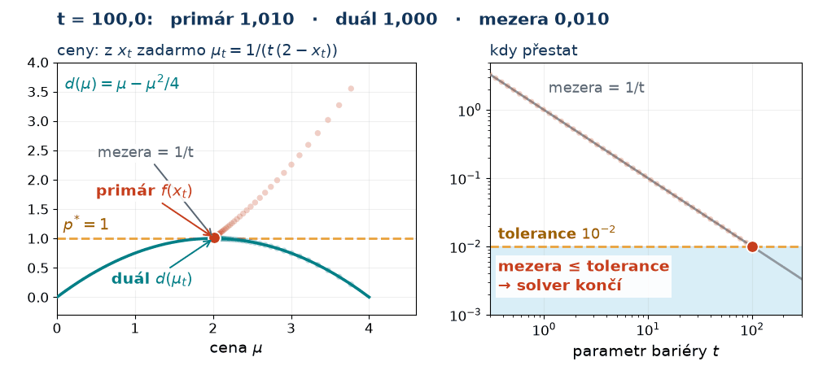

Rozdíl $p^\star-d^\star\geq0$ je **duální mezera**. U **konvexních** úloh (Slater) se zavře — **silná dualita**, $d^\star=p^\star$ — a nejlepší ceny jsou přesně multiplikátory z KKT.

**Kdy přestat počítat.** Bariéra sama nabízí ceny $\mu_i=-1/(t\,g_i)$ a mezera je přesně $m/t$ — u dávky $1/t$, u pekárny $4/t$, ta **záruka** z animace bariéry. Solver počítá, dokud mezera neklesne pod toleranci.

U nekonvexních úloh může mezera zůstat otevřená.

**Lagrangeův multiplikátor = duální proměnná = stínová cena** — jedno číslo, tři slovníky.

## Kde končí KKT a začínají heuristiky

### Kdy KKT a gradientní metody

- funkce jsou **hladké** — existují derivace;
- úloha je ideálně **konvexní**: řešení je globální a s certifikátem;
- proměnné jsou **spojité**.

*Nejmenší čtverce, ridge, SVM, plánování dávky.*

### Kdy heuristiky (přednášky 5–9)

- účel je **černá skříňka** — derivaci nikdo nedodá;
- funkce je **nespojitá** nebo má **spoustu lokálních minim**;
- proměnné jsou **celočíselné**, pořadí nebo výběr.

*Rozvrhy, návrh sekvencí, výběr příznaků, ladění hyperparametrů.*

Dualita slouží i za hranicí: u celočíselných úloh dá relaxace a její duál **dolní mez**, podle které metoda *branch and bound* zahazuje celé větve; velké úlohy se **rozdělí cenou** — každá část optimalizuje sama a sdílený zdroj si „kupuje“ za společnou cenu (dekompozice).

Platí to i obráceně: genetický algoritmus na konvexní QP je plýtvání — solver dá **přesné** řešení s certifikátem za zlomek času. Metodu volí struktura úlohy, ne móda.

## Co si odnést

1. **Zakřivení mění geometrii, ne zápis:** QP je LP plus matice $Q$ a optimum už nemusí ležet ve vrcholu.
2. **Bez omezení** vybere $\nabla f=\mathbf 0$ kandidáty a Hessián rozhodne.
3. **Omezení jde vyměnit za cenu.** Pokuta a bariéra to dělají přibližně; lineární poplatek se **správnou** cenou přesně (u konvexní úlohy) — to je lagrangián $\mathcal L=f+\sum_i\mu_ig_i$.
4. **KKT jsou pravidla správné ceny:** $\nabla_{\mathbf x}\mathcal L=\mathbf 0$, bod je přípustný, $\mu_i\geq0$ a **buď je omezení napnuté, nebo je jeho cena nulová.**
5. **Každá cena dá mez, nejlepší mez dá stínová cena** — to je dualita. Duál sestavíme lagrangiánem; u LP se prohodí $\mathbf c$ a $\mathbf b$, $A$ a $A^\mathsf T$.
6. **Pokutu a bariéru dořeší gradientní metody** z příští přednášky.

Dokážete u nové úlohy říct, **co je $Q$ a co jsou $g_i$** — a odhadnout, které omezení bude napnuté?

## Rychlá kontrola

1. Co musí splňovat matice $Q$, aby byla kvadratická úloha konvexní?
2. Gradient je v bodě nulový. Jak poznáte minimum, maximum a sedlo?
3. Proč leží penalizované řešení kousek za hranicí a bariérové kousek před ní?
4. Proč místo rostoucí pokuty stačí lineární poplatek — a co o něm musíme vědět?
5. Proč u úlohy s omezeními nestačí podmínka $\nabla f=\mathbf 0$?
6. Solver vrátí u pece $\mu_2=0$. Co to znamená a proč?
7. Napište duál LP $\min\,\mathbf c^\mathsf T\mathbf x$ za $A\mathbf x\geq\mathbf b$, $\mathbf x\geq\mathbf 0$. Co se prohodí?
8. Sestavte duální funkci k úloze $\min x^2$ za $x\geq1$. Jaká je nejlepší mez?
9. Co je duální mezera a k čemu ji solver potřebuje?

## Příště: jak se k optimu vlastně dojde

### Přednáška 4: optimalizace bez omezení

Dnes jsme se naučili optimum **poznat**. Příště se do něj naučíme **dojít**.

- gradientní a nejstrmější sestup: kterým směrem jít;
- délka kroku a hledání v jednom směru (Fibonacciho metoda);
- Newtonova metoda — dnešní Hessián v akci.

Právě tyhle metody řeší neomezené úlohy, na které jsme dnes omezenou úlohu přeložili pokutou a bariérou.

### Zdroje a reprodukovatelný kód

- S. Boyd, L. Vandenberghe: *Convex Optimization* (kap. 4, 5, 11);
- J. Nocedal, S. Wright: *Numerical Optimization* (kap. 12, 16, 17);
- J. Pfrommer a S. L. Brunton — přednáškové kurzy k optimalizaci.

Spustitelné ukázky: [pekárna jako QP](https://github.com/tomasvicar/OMM-public/blob/master/prednasky/L3/kod/qp_pekarna_cvxpy.py), [ridge a SVM](https://github.com/tomasvicar/OMM-public/blob/master/prednasky/L3/kod/qp_priklady_cvxpy.py), [pokuta a bariéra](https://github.com/tomasvicar/OMM-public/blob/master/prednasky/L3/kod/obrazky_blok7.py), [generátor obrázků](https://github.com/tomasvicar/OMM-public/blob/master/prednasky/L3/kod/generuj_obrazky.py) a [evidence ilustrací](https://github.com/tomasvicar/OMM-public/blob/master/prednasky/L3/zdroje.md).